# Building and Validating Predictive Models for Acute Kidney Injury (AKI) using PCORnet CDM (Part I)

xing song

May, 2020

### Stage 1: Data Feasibility Evaluation over GPC sites.

#### Objective 1.1: Study cohort extraction and characterization

##### Inclusion criteria:

- (IP,IS,EI) visits with length of stay (LOS) >= 2 days;
- age at visit >= 18 years old
- had at least 2 SCr measurements during stay

##### Exclusion criteria:

- initial eGFR < 15 mL/min per 1.73m^2 at visit;
- any dialysis procedure or renal transplantation prior to visit;
- received RRT within 48 hours since first SCr;
- burn patients (DX)

##### AKI Staging

AKI Stages are defined based on [KDIGO](http://www.kdigo.org/clinical_practice_guidelines/pdf/KDIGO%20AKI%20Guideline.pdf):

- AKI 1: increase in serum creatinine by >=**0.3 mg/dL** within **48 hours** OR **1.5-1.9 times** baseline^1 within **7 days**;
- AKI 2: **2.0 to 2.9 times** baseline within **7 days**;
- AKI 3: increase in serum creatinine to >= **4.0 mg/dL** within **48 hours** OR **3.0 times** baseline^1 within **7 days** OR **initiation of RRT**

*baseline is defined as initial SCr during hospitalization

##### Implementation: Extracting AKI Study Cohort

```r
#extract cohort --Table1
# by default, we assume cdm schema is on the same server as current schema,
cohort<-extract_cohort(conn,
                       cdm_db_name=config_file$cdm_db_name,
                       cdm_db_schema=config_file$cdm_db_schema,
                       start_date=params$start_date,
                       end_date=params$end_date,
                       verb=F)
```

```
## create temporary table:  AKI_INITIAL .
## create temporary table:  ALL_SCR_EGFR .
## create temporary table:  AKI_SCR_EGFR .
## create temporary table:  AKI_SCR_BASE .
## create temporary table:  EXCLUDE_ALL .
## create temporary table:  AKI_ELIGIBLE .
## create temporary table:  AKI_STAGES_DAILY .
## create temporary table:  AKI_ONSETS .
```

The above codes extracted AKI study cohort based on the “Inclusion” and “Exclusion” criteria specified above. The final output will be automatically saved in the current working directory /d1/home/xsong/AKI_CDM as “Table1.rda”. More details are included in the following consort diagram.

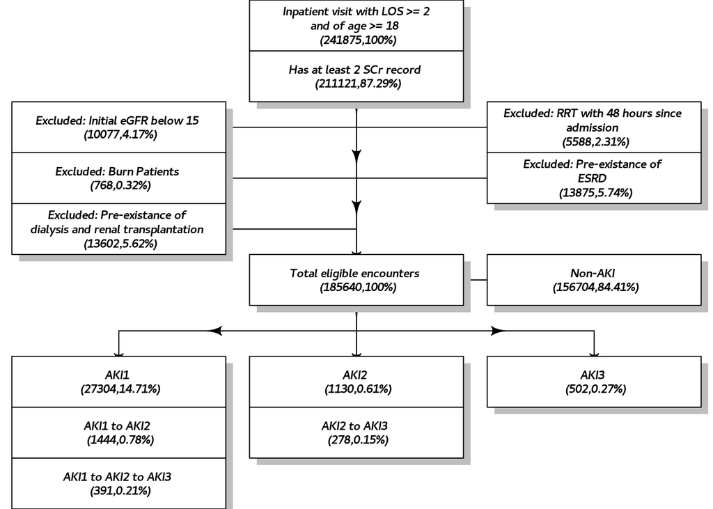

#### Objective 1.2: Variable Collection and Summaries (Table by Table)

In this section, we will collect variables from PCORNET_CDM tables: *DEMOGRAPHIC*, *ENCOUNTER*, *VITAL*, *LAB_RESULT_CM*, *PRESCRIBING MEDICATION*, *DIAGNOSIS*, *PROCEDURE*, check data quality and generate variable summaries table by table.

##### Demographic

Demographic variables include *Age (calculated from Birth_Date)*, *Sex*, *Race*, *Ethnicity*.

Table1 - Demographic Summaries at AKI1, AKI2, AKI3

| key | value | ADMIT | AKI1 | AKI2 | AKI3 | NONAKI |
| --- | --- | --- | --- | --- | --- | --- |
| **Age Group** |  |  |  |  |  |  |
| AGE_GRP | 18-25 | 8994, 4.8% | 909, 3.3% | 111, 4.3% | 76, 3.5% | 7998, 5.1% |
| AGE_GRP | 26-35 | 15428, 8.3% | 1574, 5.8% | 162, 6.3% | 143, 6.5% | 13731, 8.8% |
| AGE_GRP | 36-45 | 17954, 9.7% | 2049, 7.5% | 281, 10.9% | 226, 10.3% | 15698, 10% |
| AGE_GRP | 46-55 | 28997, 15.6% | 3811, 14% | 450, 17.5% | 347, 15.8% | 24888, 15.9% |
| AGE_GRP | 56-65 | 43759, 23.6% | 6808, 24.9% | 674, 26.2% | 624, 28.4% | 36537, 23.3% |
| AGE_GRP | 66<= | 70508, 38% | 12153, 44.5% | 896, 34.8% | 782, 35.6% | 57852, 36.9% |
| **Hispanic** |  |  |  |  |  |  |
| HISPANIC | N | 173557, 93.5% | 25683, 94.1% | 2409, 93.6% | 2045, 93% | 146355, 93.4% |
| HISPANIC | NI | 1488, 0.8% | 192, 0.7% | 28, 1.1% | 28, 1.3% | 1275, 0.8% |
| HISPANIC | Y | 10595, 5.7% | 1429, 5.2% | 137, 5.3% | 125, 5.7% | 9074, 5.8% |
| **Race** |  |  |  |  |  |  |
| RACE | 01 | 683, 0.4% | 112, 0.4% | 22, 0.9% | <11, <11 | 562, 0.4% |
| RACE | 02 | 1729, 0.9% | 246, 0.9% | 25, 1% | 17, 0.8% | 1464, 0.9% |
| RACE | 03 | 29610, 16% | 5047, 18.5% | 491, 19.1% | 458, 20.8% | 24176, 15.4% |
| RACE | 04 | 180, 0.1% | 30, 0.1% | <11, <11 | <11, <11 | 147, 0.1% |
| RACE | 05 | 138049, 74.4% | 19626, 71.9% | 1792, 69.6% | 1501, 68.3% | 117359, 74.9% |
| RACE | 06 | 318, 0.2% | 35, 0.1% | <11, <11 | <11, <11 | 280, 0.2% |
| RACE | 07 | 739, 0.4% | 123, 0.5% | <11, <11 | 14, 0.6% | 609, 0.4% |
| RACE | NI | 298, 0.2% | 44, 0.2% | <11, <11 | <11, <11 | 247, 0.2% |
| RACE | OT | 14034, 7.6% | 2041, 7.5% | 214, 8.3% | 182, 8.3% | 11860, 7.6% |
| **Sex** |  |  |  |  |  |  |
| SEX | F | 91615, 49.4% | 11920, 43.7% | 1217, 47.3% | 785, 35.7% | 78982, 50.4% |
| SEX | M | 94023, 50.6% | 15384, 56.3% | 1357, 52.7% | 1413, 64.3% | 77720, 49.6% |
| SEX | NI | <11, <11 | 0, 0% | 0, 0% | 0, 0% | <11, <11 |
| **Total** |  |  |  |  |  |  |
| TOTAL | (%/overall) | 185640, 100% | 27304, 14.7% | 2574, 1.4% | 2198, 1.2% | 156704, 84.4% |

Demographic characterizations for patients at different AKI stages are summarized in Table 1.

##### Vital

Vital variables include: *Height*, *Weight*, *BMI*, *Blood Pressure (Systolic, Diastolic)*, *Smoking Status*.

Table 2a - Vital (HT,WT,BMI,SBP,DBP) Summaries

| days_from_admit | 1.encounters# | 2.records# | 3.low_records# | 4.high_records# | 5a.min | 5b.median | 5c.mean | 5d.sd | 5e.cov | 5f.max |
| --- | --- | --- | --- | --- | --- | --- | --- | --- | --- | --- |
| **BMI** |  |  |  |  |  |  |  |  |  |  |
| 0> | 45919 | 60676 | <11 | 1037 | 2 | 28 | 31 | 223 | 7.2 | 36106 |
| 1 | 178762 | 178762 | <11 | 3957 | 2 | 28 | 31 | 260 | 8.4 | 73000 |
| 2 | 9165 | 9165 | <11 | 203 | 2 | 28 | 30 | 10 | 0.3 | 287 |
| 3 | 7054 | 7054 | <11 | 122 | 12 | 28 | 29 | 10 | 0.3 | 405 |
| 4 | 5652 | 5652 | <11 | 97 | 13 | 28 | 29 | 8 | 0.3 | 174 |
| 5 | 3199 | 3199 | <11 | 50 | 9 | 28 | 30 | 8 | 0.3 | 213 |
| 6 | 2886 | 2886 | <11 | 46 | 13 | 28 | 30 | 9 | 0.3 | 284 |
| 7 | 3049 | 3049 | <11 | 51 | 13 | 29 | 30 | 8 | 0.3 | 238 |
| 7< | 17815 | 28075 | <11 | 394 | 4 | 29 | 31 | 119 | 3.8 | 19051 |
| overall | 183114 | 298518 | <11 | 5957 | 2 | 28 | 31 | 228 | 7.4 | 73000 |
| **BP_DIASTOLIC** |  |  |  |  |  |  |  |  |  |  |
| 0> | 58530 | 739346 | 4914 | 1899 | 0 | 70 | 71 | 14 | 0.2 | 232 |
| 1 | 148852 | 1235358 | 11848 | 12606 | 0 | 73 | 74 | 17 | 0.2 | 229 |
| 2 | 140058 | 1613553 | 15812 | 4949 | 0 | 69 | 70 | 15 | 0.2 | 236 |
| 3 | 135897 | 1170702 | 9666 | 2308 | 0 | 68 | 69 | 14 | 0.2 | 220 |
| 4 | 112599 | 902496 | 7182 | 1701 | 0 | 69 | 70 | 14 | 0.2 | 206 |
| 5 | 89690 | 697478 | 5737 | 1140 | 0 | 69 | 70 | 14 | 0.2 | 200 |
| 6 | 71716 | 548975 | 4332 | 770 | 5 | 69 | 69 | 14 | 0.2 | 209 |
| 7 | 58229 | 449397 | 3555 | 657 | 0 | 68 | 69 | 14 | 0.2 | 216 |
| 7< | 76832 | 3574698 | 30140 | 4742 | 0 | 68 | 69 | 14 | 0.2 | 229 |
| overall | 185599 | 10932003 | 93186 | 30772 | 0 | 69 | 70 | 15 | 0.2 | 236 |
| **BP_SYSTOLIC** |  |  |  |  |  |  |  |  |  |  |
| 0> | 58530 | 739346 | <11 | 656 | 32 | 125 | 126 | 21 | 0.2 | 467 |
| 1 | 148852 | 1235358 | 20 | 6021 | 0 | 127 | 129 | 25 | 0.2 | 313 |
| 2 | 140058 | 1613553 | 19 | 1435 | 0 | 123 | 125 | 22 | 0.2 | 270 |
| 3 | 135897 | 1170702 | <11 | 508 | 0 | 123 | 125 | 21 | 0.2 | 288 |
| 4 | 112599 | 902496 | <11 | 392 | 36 | 124 | 125 | 21 | 0.2 | 270 |
| 5 | 89690 | 697478 | <11 | 295 | 31 | 124 | 125 | 21 | 0.2 | 292 |
| 6 | 71716 | 548975 | <11 | 202 | 31 | 123 | 125 | 21 | 0.2 | 250 |
| 7 | 58229 | 449397 | <11 | 174 | 32 | 123 | 125 | 20 | 0.2 | 261 |
| 7< | 76832 | 3574698 | 29 | 1216 | 0 | 123 | 124 | 20 | 0.2 | 467 |
| overall | 185599 | 10932003 | 91 | 10899 | 0 | 124 | 125 | 21 | 0.2 | 467 |
| **HT** |  |  |  |  |  |  |  |  |  |  |
| 0> | 43599 | 55754 | <11 | <11 | 2 | 67 | 67 | 4 | 0.1 | 97 |
| 1 | 171637 | 171637 | <11 | <11 | 1 | 67 | 67 | 4 | 0.1 | 118 |
| 2 | 8690 | 8690 | <11 | <11 | 24 | 67 | 67 | 4 | 0.1 | 83 |
| 3 | 6610 | 6610 | <11 | <11 | 23 | 67 | 67 | 4 | 0.1 | 81 |
| 4 | 5331 | 5331 | <11 | <11 | 34 | 67 | 67 | 4 | 0.1 | 81 |
| 5 | 3031 | 3031 | <11 | <11 | 27 | 67 | 67 | 4 | 0.1 | 83 |
| 6 | 2742 | 2742 | <11 | <11 | 25 | 67 | 67 | 4 | 0.1 | 80 |
| 7 | 2911 | 2911 | <11 | <11 | 27 | 67 | 67 | 4 | 0.1 | 81 |
| 7< | 17490 | 27171 | <11 | <11 | 6 | 67 | 67 | 4 | 0.1 | 83 |
| overall | 178952 | 283877 | <11 | <11 | 1 | 67 | 67 | 4 | 0.1 | 118 |
| **WT** |  |  |  |  |  |  |  |  |  |  |
| 0> | 46194 | 60961 | <11 | 509 | 10 | 180 | 188 | 53 | 0.3 | 1262 |
| 1 | 180917 | 180917 | <11 | 2425 | 10 | 180 | 188 | 56 | 0.3 | 1463 |
| 2 | 9174 | 9174 | <11 | 121 | 12 | 180 | 189 | 56 | 0.3 | 1374 |
| 3 | 7065 | 7065 | <11 | 74 | 60 | 180 | 187 | 53 | 0.3 | 580 |
| 4 | 5654 | 5654 | <11 | 56 | 70 | 179 | 186 | 53 | 0.3 | 567 |
| 5 | 3199 | 3199 | <11 | 25 | 55 | 184 | 191 | 53 | 0.3 | 544 |
| 6 | 2887 | 2887 | <11 | 30 | 75 | 184 | 191 | 52 | 0.3 | 521 |
| 7 | 3050 | 3050 | <11 | 31 | 75 | 185 | 191 | 53 | 0.3 | 668 |
| 7< | 17815 | 28051 | <11 | 220 | 19 | 188 | 193 | 52 | 0.3 | 620 |
| overall | 185125 | 300958 | <11 | 3491 | 10 | 181 | 189 | 55 | 0.3 | 1463 |

Table 2a identifies extreme values of vitals for height, weight, BMI, and blood pressure, which may suggest systemic errors such as typos, and conversion mistakes. Here is the list of how *high* and *low* vitals are defined (adopted from CDM EDC report):

| vital type | upper bound for low values | lower bound for high values |
| --- | --- | --- |
| HT(inches) | 0 | 95 |
| WT(lbs) | 0 | 350 |
| BMI | 0 | 50 |
| BP_DIASTOLIC | 40 | 120 |
| BP_SYSTOLIC | 40 | 210 |

Table 2b - Vital (SMOKING, TABACCO) Summaries

| key_cat | 1.patients# | 2.encounters# | 3.encounters% |
| --- | --- | --- | --- |
| **SMOKING** |  |  |  |
| SMOKING_01,03,NI | 693 | 729 | 0.4% |
| SMOKING_NI | 42773 | 59126 | 31.8% |
| SMOKING_02,03,NI | 539 | 561 | 0.3% |
| SMOKING_08,NI | 418 | 555 | 0.3% |
| SMOKING_03,NI | 28616 | 50228 | 27.1% |
| SMOKING_02,NI | 29691 | 50156 | 27% |
| SMOKING_03,08,NI | 45 | 48 | 0% |
| SMOKING_03,06,NI | 37 | 38 | 0% |
| SMOKING_02,06,NI | 30 | 31 | 0% |
| SMOKING_06,NI | 279 | 287 | 0.2% |
| SMOKING_01,NI | 15325 | 23305 | 12.6% |
| SMOKING_02,08,NI | 21 | 21 | 0% |
| SMOKING_01,06,NI | 17 | 17 | 0% |
| SMOKING_07,NI | 119 | 167 | 0.1% |
| SMOKING_05,NI | 135 | 165 | 0.1% |
| SMOKING_01,02,NI | 138 | 144 | 0.1% |
| **TOBACCO** |  |  |  |
| TOBACCO_01,03,NI | 77 | 81 | 0% |
| TOBACCO_NI | 53375 | 75559 | 40.7% |
| TOBACCO_01,02,NI | 70 | 71 | 0% |
| TOBACCO_03,NI | 3421 | 5736 | 3.1% |
| TOBACCO_01,NI | 1936 | 2801 | 1.5% |
| TOBACCO_02,03,NI | 237 | 241 | 0.1% |
| TOBACCO_02,NI | 56690 | 101147 | 54.5% |
| **TOBACCO_TYPE** |  |  |  |
| TOBACCO_TYPE_NI | 53438 | 75658 | 40.8% |
| TOBACCO_TYPE_01,NI | 38217 | 64529 | 34.8% |
| TOBACCO_TYPE_02,04,NI | 48 | 49 | 0% |
| TOBACCO_TYPE_03,04,NI | 46 | 48 | 0% |
| TOBACCO_TYPE_04,NI | 23061 | 41446 | 22.3% |
| TOBACCO_TYPE_01,03,NI | 39 | 40 | 0% |
| TOBACCO_TYPE_02,03,NI | 26 | 27 | 0% |
| TOBACCO_TYPE_03,NI | 1251 | 1713 | 0.9% |
| TOBACCO_TYPE_01,02,NI | 13 | 14 | 0% |
| TOBACCO_TYPE_05,NI | <11 | 11 | 0% |
| TOBACCO_TYPE_01,04,NI | 997 | 1050 | 0.6% |
| TOBACCO_TYPE_02,NI | 707 | 1047 | 0.6% |

Table 2b identifies unreliable reporting of smoking status. A significant number of conflicting status or mismatch between smoking and tabacco summaries requires some further investigation.

##### Labs

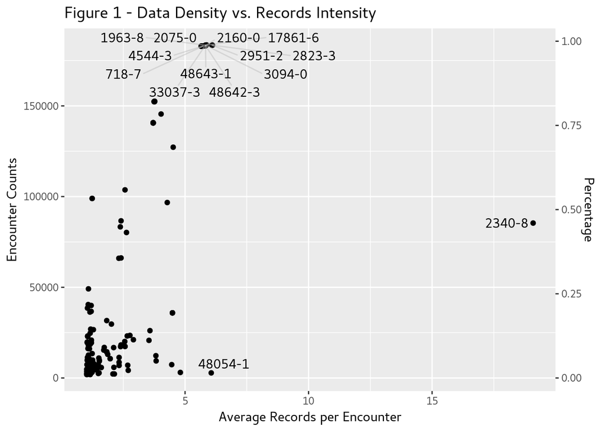

*Note that only labs with coverage above 1% of the overall cohort are included in the plot, the complete distribution can be found in the accompanied excel file.*

##### Diagnosis

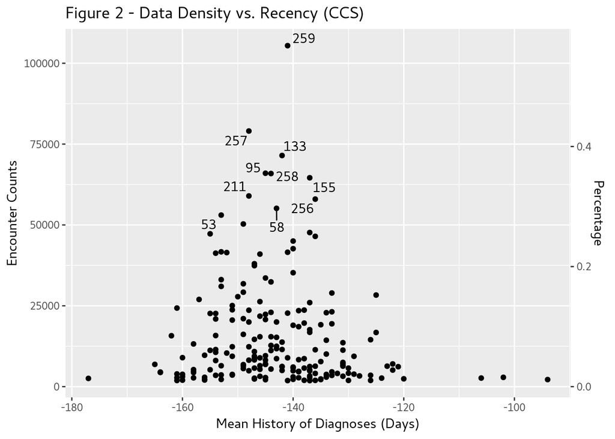

A Total of 281 distinct CCS-grouped diagnoses has been assigned to patients before the encounter of interest. Figure 2 gives an overview of average history of patients’ diagnosis prior to tne encounter of interest as well as the highly frequent historical diagnoses(e.g. 259(Residual codes; unclassified), 257(Other aftercare), 133(Other lower respiratory disease), 95(Other nervous system disorders), 258(Other screening for suspected conditions (not mental disorders or infectious disease)), 155(Other gastrointestinal disorders)).

*Note that only ccs diagnosis codes with coverage above 1% of the overall cohort are included in the plot, the complete distribution can be found in the accompanied excel file.*

##### Procedure

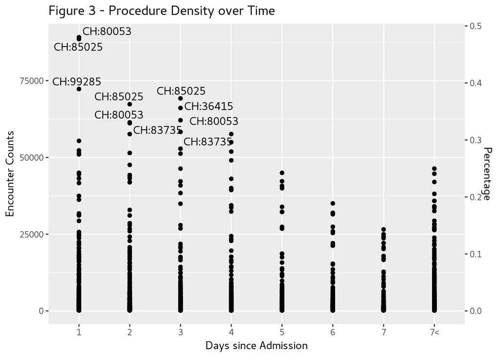

A Total of 6583 distinct total procedures codes have been assigned to patients during the encounter of interest. Figure3 gives an overview of procedures that patients had recieved before or at the encounters of interest. It can help identify the common procedures or typical occuring times of precedures (e.g. [CH:80053](https://coder.aapc.com/cpt-codes/), [CH:85025](https://coder.aapc.com/cpt-codes/),[CH:99285](https://coder.aapc.com/cpt-codes/),[CH:36415](https://coder.aapc.com/cpt-codes/),[CH:83735](https://coder.aapc.com/cpt-codes/),…).

*Note that only procedure codess with coverage above 0.1% of the overall cohort are included in the plot, the complete distribution can be found in the accompanied excel file.*

##### Medications

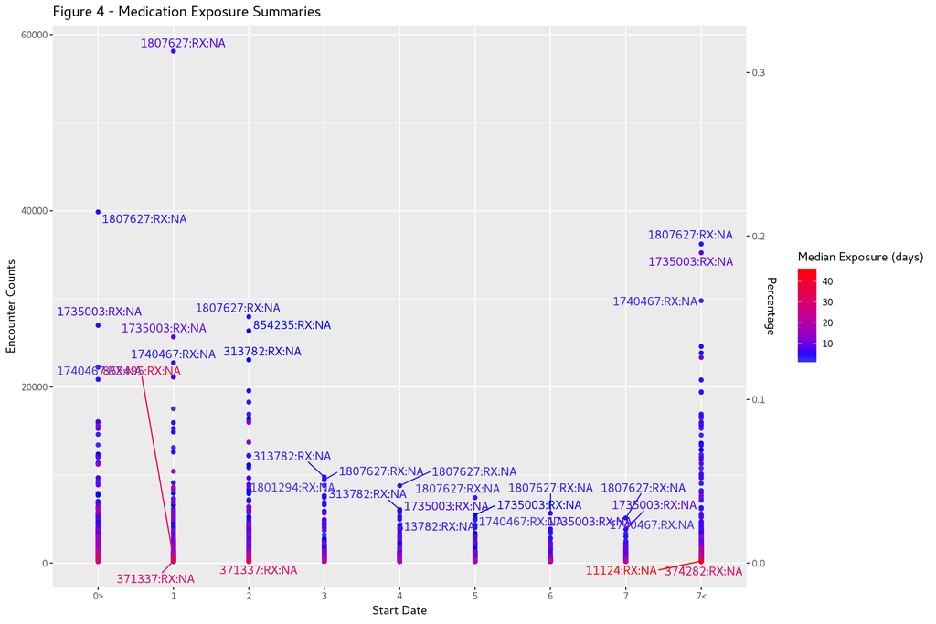

A Total of 3696 distinct RXNORM medication concepts are discovered for the cohort and the overall medication (any) exposure for this cohort is 99%. Figure4 demonstrates average exposures for drug starting at X days since admission. It helps identify typical medciations administered during the course of stay. (e.g. the typical medications identified are 1807627(150 ML sodium chloride 9 MG/ML Injection),1735003(2 ML fentanyl 0.05 MG/ML Injection),1740467(2 ML ondansetron 2 MG/ML Injection); while drugs such as 11124(vancomycin),855495(amylase 120000 UNT / lipase 24000 UNT / protease 76000 UNT Delayed Release Oral Capsule),371337(ceftazidime Injectable Solution)are used with a relative longer exposure than the others).

*Note that only rxnorms with coverage above 0.1% of the overall cohort are included in the plot, the complete distribution can be found in the accompanied excel file.*